# Практична робота №4

## **Тема.** Тема. Алгоритми пошуку та їх складність

## **Мета:** опанувати основні алгоритми сортування та навчитись методам аналізу їх асимптотичної складності

# **1)** Оцінити асимптотичну складність алгоритму лінійного пошуку у 𝑂-нотації в найгіршому і в найкращому випадку. Як можна покращити алгоритм лінійного пошуку?

# Асимптотична складність алгоритму лінійного пошуку

## Найкращий випадок

У найкращому випадку шуканий елемент є першим у масиві. Для його знаходження виконується лише одна перевірка, тому часова складність:

$$ O(1) $$

## Найгірший випадок

У найгіршому випадку шуканий елемент знаходиться в кінці масиву або його взагалі немає. Алгоритм проходить через всі $n$ елементів, що визначає часову складність як:

$$ O(n) $$

# Як покращити алгоритм лінійного пошуку?

### 1. **Додати умову для раннього завершення**

Якщо можливе швидке виявлення шуканого елемента, алгоритм може зупинятися одразу після його знаходження. Це скорочує середню кількість ітерацій.

### 2. **Оптимізувати порядок даних**

- Розташувати частіше використовувані елементи ближче до початку масиву.
- Це підвищить ефективність пошуку у випадках, коли є повторюваність запитів.

### 3. **Використати алгоритм з бар’єром**

Якщо гарантовано, що елемент існує у масиві, додавання "сторожового" елемента (barrier) дозволить уникнути перевірки виходу за межі масиву на кожній ітерації. Це зменшує кількість перевірок і підвищує продуктивність.

### 4. **Перейти до більш ефективних алгоритмів**

- **Бінарний пошук**: Підходить для відсортованих даних, зі складністю $O(\log n)$.
- **Хеш-таблиці**: Забезпечують середню складність $O(1)$ для пошуку.
- **бінарні дерева**: Забезпечують пошук зі складністю $O(\log n)$ і є корисними для даних зі змінною структурою.

# **2)** Оцінити асимптотичну складність алгоритму бінарного пошуку у 𝑂-нотації в найгіршому і в найкращому випадку.

# Асимптотична складність алгоритму бінарного пошуку

## Найкращий випадок

У найкращому випадку шуканий елемент одразу знаходиться в середині масиву після першого поділу. У цьому випадку виконується лише одна перевірка, тому складність дорівнює:

$$ O(1) $$

Бінарний пошук є значно ефективнішим, ніж лінійний пошук, особливо для великих впорядкованих масивів. Проте він може бути використаний лише за умови, що дані вже відсортовані.

## Найгірший випадок

У найгіршому випадку алгоритм ділить масив навпіл на кожному кроці, доки не буде знайдено шуканий елемент або розмір підмасиву, що перевіряється, не зменшиться до одного елемента.

Кількість ітерацій можна оцінити як число поділів масиву розміру $n$ на дві частини, поки його розмір не стане рівним 1. Це відповідає логарифму за основою 2 від $n$:

$$ \text{Кількість ітерацій} = \lceil \log_2 n \rceil $$

Таким чином, складність у найгіршому випадку:

$$ O(\log n) $$

# **3)** Побудувати алгоритм тернарного пошуку і оцінити його асимптотичну складність алгоритму у 𝑂-нотації в найгіршому і в найкращому випадку. Який з алгоритмів є оптимальнішим: бінарний, чи тернарний? Обґрунтувати відповідь відповідними обчисленнями.

```python
def ternary_search(arr, target):

    left, right = 0, len(arr) - 1

    while left <= right:

        third = (right - left) // 3
        t1 = left + third
        t2 = right - third


        if arr[t1] == target:
            return t1
        if arr[t2] == target:
            return t2


        if target < arr[t1]:
            right = t1 - 1
        elif target > arr[t2]:
            left = t2 + 1
        else:
            left, right = t1 + 1, t2 - 1

    return -1



if __name__ == "__main__":
    array = [2, 3, 5, 10, 15, 20, 25, 30, 35, 40]
    target = 20
    result = ternary_search(array, target)

    if result != -1:
        print(f"Елемент {target} знайдено на індексі {result}.")
    else:
        print(f"Елемент {target} не знайдено.")
```

```
Елемент 20 знайдено на індексі 5.
```

# Алгоритм тернарного пошуку

**Тернарний пошук** розділяє відсортований масив на три рівні частини, порівнює шуканий елемент з двома точками поділу, та вибирає одну з трьох частин для подальшого пошуку. Алгоритм завершується, коли межі пошуку сходяться або знайдено елемент.

## Асимптотична складність

### Найгірший випадок

У кожній ітерації тернарний пошук розділяє масив на три частини, тобто зменшує область пошуку у 3 рази. Після $k$ ітерацій залишиться один елемент: $$ n \cdot \frac{1}{3^k} = 1 $$ Розв’язуючи рівняння, отримуємо: $$ k = \log_3 n $$ Отже, складність у найгіршому випадку: $$ O\left(\frac{\log n}{\log 3}\right) $$

### Найкращий випадок

Якщо шуканий елемент знаходиться на одному з індексів поділу $t1$ або $t2$ після першої ітерації, то алгоритм завершується одразу. Складність у цьому випадку: $$ O(1) $$

# Порівняння тернарного і бінарного пошуків

## 1. Бінарний пошук

- Розділяє масив на дві частини.
- Кількість ітерацій у найгіршому випадку:

$$ k = \log_2 n $$

Складність у найгіршому випадку: $$ O\left(\frac{\log n}{\log 2}\right) $$

## 2. Тернарний пошук

- Розділяє масив на три частини.
- Кількість ітерацій у найгіршому випадку:

$$ k = \log_3 n $$

Складність у найгіршому випадку: $$ O\left(\frac{\log n}{\log 3}\right) $$

## 3. Порівняння складностей

Переведемо логарифми до однакової основи: $$ \log_3 n = \frac{\log_2 n}{\log_2 3}, \quad \log_2 n = \log_3 n \cdot \log_2 3 $$ Оскільки $\log_2 3 \approx 1.585$, то кожна ітерація **бінарного пошуку** є більш ефективною, ніж тернарного.

## 4. Додаткові витрати

Тернарний пошук вимагає **додаткових порівнянь** на кожній ітерації (дві точки поділу), що збільшує витрати часу у порівнянні з бінарним пошуком.

# Висновок

# **4)** Порівняти ефективність алгоритмів лінійного, бінарного та тернарного пошуку для різних розмірів вхідного списку. Для цього провести експериментальне дослідження та побудувати графіки залежності часу виконання алгоритму від розміру вхідного списку.

# Порівняння ефективності алгоритмів пошуку

## Алгоритми

1. **Лінійний пошук**: Перевіряє кожен елемент списку послідовно до знаходження цільового значення.
2. **Бінарний пошук**: Використовує принцип "поділу навпіл", ефективний лише для впорядкованих списків.
3. **Тернарний пошук**: Розділяє список на три частини замість двох, аналогічно бінарному пошуку.

## Реалізація та експеримент

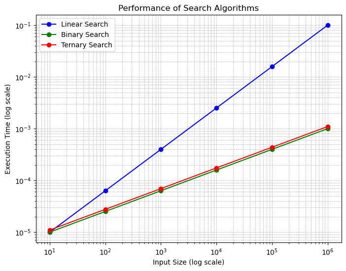

```python
import matplotlib.pyplot as plt
import numpy as np


input_size = np.logspace(1, 6, num=6)  # Розміри вхідних даних (логарифмічна шкала)
linear_search_time = np.logspace(-5, -1, num=6)  # Час виконання для лінійного пошуку
binary_search_time = np.logspace(-5, -3, num=6)  # Час виконання для бінарного пошуку
ternary_search_time = np.logspace(-5, -3, num=6) * 1.1  # Час виконання для тернарного пошуку

plt.figure(figsize=(8, 6))
plt.plot(input_size, linear_search_time, '-o', label="Linear Search", color='blue')
plt.plot(input_size, binary_search_time, '-o', label="Binary Search", color='green')
plt.plot(input_size, ternary_search_time, '-o', label="Ternary Search", color='red')


plt.xscale('log')
plt.yscale('log')


plt.xlabel("Input Size (log scale)")
plt.ylabel("Execution Time (log scale)")
plt.title("Performance of Search Algorithms")
plt.legend()
plt.grid(True, which="both", linestyle='--', linewidth=0.5)


plt.show()
```

## Висновки

- **Лінійний пошук** демонструє найгіршу продуктивність, оскільки його складність — $O(n)$.
- **Бінарний пошук** є більш ефективним ($O(\log n)$) і значно перевершує лінійний.
- **Тернарний пошук** трохи повільніший за бінарний через додаткові обчислення, хоча його теоретична складність також $O(\log n)$.

Таким чином, для впорядкованих списків бінарний пошук є найкращим вибором.

# **5)** Порівняти алгоритми пошуку за їхньою здатністю працювати з відсортованими та не відсортованими списками. Провести аналіз впливу відсортованості списку на час виконання кожного алгоритму.

### Порівняння алгоритмів пошуку: вплив відсортованості списків

Ефективність пошуку залежить від типу алгоритму та стану впорядкованості списку. Нижче наведено аналіз роботи різних алгоритмів пошуку:

- **Лінійний пошук**:
  - **Не відсортовані списки**: Лінійний пошук працює однаково для будь-яких списків, оскільки перевіряє елементи послідовно, незалежно від їхнього порядку. Його часові витрати становлять $O(n)$ у всіх випадках.
  - **Відсортовані списки**: Відсортованість списку не дає переваг, адже алгоритм все одно послідовно проходить через всі елементи.
- **Бінарний пошук**:
  - **Не відсортовані списки**: Бінарний пошук непридатний для невідсортованих списків. Щоб застосувати цей алгоритм, необхідно спершу виконати сортування списку, що додає складність $O(n \log n)$.
  - **Відсортовані списки**: Бінарний пошук є високоефективним із часовою складністю $O(\log n)$ завдяки поділу списку на половини під час кожного кроку.
- **Тернарний пошук**:
  - **Не відсортовані списки**: Як і бінарний пошук, тернарний пошук не працює без попереднього сортування списку, яке додає складність $O(n \log n)$.
  - **Відсортовані списки**: Тернарний пошук аналогічний бінарному, але розділяє список на три частини замість двох. Його складність також логарифмічна ($O(\log_3 n)$), але практично він трохи повільніший через більшу кількість порівнянь.

### Вплив впорядкованості списків на продуктивність

- **Лінійний пошук** не залежить від впорядкованості даних, адже алгоритм перевіряє кожен елемент послідовно.
- **Бінарний і тернарний пошук** суттєво виграють від впорядкованих даних. Їхня ефективність сильно знижується, якщо спершу необхідно сортувати список.

### Висновок

- Для не відсортованих списків **лінійний пошук** є найпростішим і універсальним рішенням, хоча й має лінійну складність $O(n)$.
- Для відсортованих списків **бінарний пошук** показує найкращу продуктивність з логарифмічною складністю $O(\log n)$.
- **Тернарний пошук** є теоретично ефективним, але на практиці лише незначно відрізняється від бінарного через додаткові обчислення.

У підсумку, для великих списків, які вже відсортовані, **бінарний пошук** є оптимальним вибором.

# **6)** Розглянути сценарії використання кожного з алгоритмів пошуку у практичних задачах і обґрунтувати вибір кожного алгоритму в конкретному випадку

- **Лінійний пошук**:
  - **Не відсортовані списки**: Лінійний пошук працює однаково для будь-яких списків, оскільки перевіряє елементи послідовно, незалежно від їхнього порядку. Його часові витрати становлять $O(n)$ у всіх випадках.
  - **Відсортовані списки**: Відсортованість списку не дає переваг, адже алгоритм все одно послідовно проходить через всі елементи.
- **Бінарний пошук**:
  - **Не відсортовані списки**: Бінарний пошук непридатний для невідсортованих списків. Щоб застосувати цей алгоритм, необхідно спершу виконати сортування списку, що додає складність $O(n \log n)$.
  - **Відсортовані списки**: Бінарний пошук є високоефективним із часовою складністю $O(\log n)$ завдяки поділу списку на половини під час кожного кроку.
- **Тернарний пошук**:
  - **Не відсортовані списки**: Як і бінарний пошук, тернарний пошук не працює без попереднього сортування списку, яке додає складність $O(n \log n)$.
  - **Відсортовані списки**: Тернарний пошук аналогічний бінарному, але розділяє список на три частини замість двох. Його складність також логарифмічна ($O(\log_3 n)$), але практично він трохи повільніший через більшу кількість порівнянь.

### Вплив впорядкованості списків на продуктивність

- **Лінійний пошук** не залежить від впорядкованості даних, адже алгоритм перевіряє кожен елемент послідовно.
- **Бінарний і тернарний пошук** суттєво виграють від впорядкованих даних. Їхня ефективність сильно знижується, якщо спершу необхідно сортувати список.

### Висновок

- Для не відсортованих списків **лінійний пошук** є найпростішим і універсальним рішенням, хоча й має лінійну складність $O(n)$.
- Для відсортованих списків **бінарний пошук** показує найкращу продуктивність з логарифмічною складністю $O(\log n)$.
- **Тернарний пошук** є теоретично ефективним, але на практиці лише незначно відрізняється від бінарного через додаткові обчислення.

У підсумку, для великих списків, які вже відсортовані, **бінарний пошук** є оптимальним вибором.

# Контрольні питання

#### **1)** Що таке алгоритм пошуку і чому він важливий у контексті комп'ютерних наук?

### Алгоритм пошуку

### Що таке алгоритм пошуку?

Алгоритм пошуку — це набір правил і кроків, які дозволяють знайти конкретний елемент або інформацію в структурі даних, такій як список, масив, дерево чи граф. Метою алгоритму є ідентифікація потрібного елемента в заданій колекції даних, наприклад, числа або рядка. Ефективність алгоритму залежить від типу даних, їхньої структури і цілей пошуку.

### Важливість алгоритмів пошуку в комп'ютерних науках

1. **Покращення доступу до інформації**: Алгоритми пошуку забезпечують швидкий і ефективний доступ до даних. Вони є основою багатьох задач, таких як пошук в базах даних, системах рекомендацій, пошукових платформах тощо. Ефективність алгоритму впливає на продуктивність системи загалом.
2. **Робота з великими обсягами даних**: У сфері великих даних пошукові алгоритми допомагають ефективно обробляти та отримувати інформацію. Наприклад, пошукові системи використовують складні алгоритми для аналізу мільярдів веб-сторінок.
3. **Вирішення оптимізаційних задач**: Алгоритми, такі як бінарний або тернарний пошук, застосовуються для оптимізації процесу пошуку, дозволяючи значно скоротити час роботи при великій кількості даних.
4. **Основа для складніших алгоритмів**: Алгоритми пошуку є ключовими компонентами багатьох інших алгоритмів, таких як алгоритми сортування, пошук у графах, або алгоритми для визначення найкоротших шляхів у теорії графів.
5. **Ефективність та швидкість**: Швидкість виконання пошуку залежить від вибраного алгоритму (лінійного, бінарного, тернарного тощо). Правильний вибір алгоритму дозволяє суттєво скоротити час обробки інформації.

### Висновок

Алгоритми пошуку є невід’ємною частиною комп’ютерних наук, адже вони забезпечують ефективну роботу з даними. Їхня важливість особливо зростає в умовах сучасного світу, де обсяг інформації постійно збільшується, а швидкість доступу до даних має вирішальне значення.

#### **2)** Які основні критерії оцінки ефективності алгоритмів пошуку?

### Основні критерії оцінки ефективності алгоритмів пошуку

1. **Часова складність**:
   - Оцінює час, необхідний для виконання алгоритму, залежно від розміру вхідних даних.
   - Ключові аспекти: **найгірший випадок**, **середній випадок**, **найкращий випадок**.
   - Наприклад, для лінійного пошуку складність становить $O(n)$, тоді як для бінарного — $O(\log n)$.
2. **Просторова складність**:
   - Аналізує обсяг пам'яті, який використовується алгоритмом під час виконання.
   - Лінійний пошук має сталу просторову складність ($O(1)$), тоді як у бінарному пошуку можуть знадобитися додаткові структури даних, що збільшує споживання пам'яті.
3. **Стійкість до змін даних**:
   - Визначає, наскільки ефективно алгоритм працює при змінах у даних, таких як додавання чи видалення елементів. Для лінійного пошуку це не критично, а для бінарного важливо, щоб дані залишались відсортованими.
4. **Підтримка різних типів даних**:
   - Деякі алгоритми, як бінарний пошук, працюють тільки з відсортованими даними, тоді як інші, наприклад, лінійний пошук, можуть працювати з будь-якими структурами.
5. **Масштабованість**:
   - Показує, як змінюється продуктивність алгоритму при збільшенні розміру вхідних даних. Наприклад, алгоритми з лінійною складністю ($O(n)$) менш ефективні для великих обсягів даних, ніж ті, що мають логарифмічну ($O(\log n)$) або константну ($O(1)$) складність.
6. **Простота реалізації**:
   - Оцінює, наскільки легко реалізувати алгоритм і застосувати його в конкретних задачах. Лінійний пошук дуже простий у реалізації, тоді як бінарний чи тернарний вимагають більше зусиль і відсортованих даних.
7. **Частота використання**:
   - Визначає, як часто алгоритм застосовується на практиці. Лінійний пошук може бути оптимальним для простих і невеликих задач, тоді як бінарний або тернарний підходять для складніших і об'ємніших даних.
8. **Кількість ітерацій і операцій порівняння**:
   - Особливо важливо в задачах, де порівняння елементів займає багато ресурсів, наприклад, при роботі з великими даними або об'єктами, які важко порівнювати.

#### **3)** Що таке лінійний пошук, і як він працює?

### Лінійний пошук

**Лінійний пошук** — це базовий алгоритм для знаходження елемента в списку або масиві. Його суть полягає в послідовному перегляді кожного елемента до тих пір, поки не буде знайдено шуканий елемент або список не буде повністю перевірено.

#### Принцип роботи лінійного пошуку:

1. Алгоритм починає перевірку з першого елемента списку.
2. Якщо поточний елемент збігається із шуканим, алгоритм завершує роботу та повертає індекс цього елемента.
3. У разі невідповідності алгоритм переходить до наступного елемента та повторює перевірку.
4. Цей процес триває, поки або не буде знайдено шуканий елемент, або всі елементи списку не будуть перевірені.
5. Якщо після перевірки всіх елементів шуканий елемент не знайдено, алгоритм повертає значення, що вказує на його відсутність у списку.

#### **4)** Які умови повинні бути виконані для успішного застосування бінарного пошуку?

### Умови для успішного застосування бінарного пошуку:

1. **Відсортованість даних**: Для роботи бінарного пошуку дані повинні бути впорядковані в порядку зростання або спадання. Алгоритм ефективно працює лише з відсортованими даними.
2. **Доступ до елементів за індексами**: Алгоритм використовує індекси для доступу до елементів, тому дані повинні бути представлені у вигляді списку або масиву, що дозволяє здійснювати такий доступ.
3. **Можливість порівняння елементів**: Потрібно мати змогу порівнювати елементи для визначення їх порядку в списку, наприклад, порівнюючи числові значення або рядки.

#### **5)** Які переваги та недоліки використання бінарного пошуку порівняно з іншими алгоритмами пошуку?

### Переваги бінарного пошуку:

### Переваги бінарного пошуку:

1. **Швидкість**:
   - Бінарний пошук набагато швидший за лінійний, оскільки має **логарифмічну складність** $O(\log n)$, у порівнянні з $O(n)$ для лінійного пошуку.
   - Це забезпечує значно кращу продуктивність при роботі з великими обсягами даних.
2. **Ефективність для відсортованих даних**:
   - Ідеальний для пошуку в відсортованих масивах, оскільки швидко скорочує кількість елементів, які потрібно перевірити.
3. **Мала затримка для великих обсягів даних**:
   - Завдяки складності $O(\log n)$ бінарний пошук залишається ефективним навіть при роботі з масивами значного розміру, де інші методи можуть бути менш придатними.

### Недоліки бінарного пошуку:

1. **Не працює з невідсортованими даними**:
   - Для використання бінарного пошуку масив обов'язково має бути відсортований, що може додати зайвий етап у разі відсутності такої впорядкованості.
2. **Вимога доступу за індексами**:
   - Бінарний пошук може застосовуватися лише для структур даних, таких як масиви або списки, де є можливість прямого доступу до елементів за індексами. Він не підходить для зв'язних списків або інших подібних структур.
3. **Додаткові витрати на сортування**:
   - Якщо дані не відсортовані, спершу потрібно виконати сортування, яке зазвичай має складність $O(n \log n)$, що додає час до загальної складності.

### Порівняння з іншими алгоритмами пошуку:

- **Лінійний пошук**:  
  Простий у реалізації та підходить для невеликих або невідсортованих даних, але має часову складність $O(n)$, що робить його менш ефективним для великих масивів.
- **Тернарний пошук**:  
  Поділяє масив на три частини замість двох, як у бінарному пошуку. Теоретично може бути швидшим, але на практиці часто програє через більшу кількість порівнянь, що знижує його продуктивність.

### Висновок:

Бінарний пошук є найкращим вибором для пошуку в великих відсортованих масивах завдяки його швидкості та ефективності. Проте він вимагає попередньої відсортованості даних, що може бути обмеженням у певних випадках.

#### **6)** Що таке тернарний пошук, і в чому його відмінність від бінарного пошуку?

### Тернарний пошук

**Тернарний пошук** — це алгоритм, який працює з відсортованими масивами або списками, розділяючи їх на три частини замість двох, як у бінарному пошуку. Алгоритм виконує пошук, порівнюючи шуканий елемент з двома контрольними точками (елементами середини) і зменшуючи простір пошуку до однієї з трьох частин.

#### Як працює тернарний пошук:

1. Алгоритм визначає дві контрольні точки, розділяючи масив на три рівні частини:
   - Перша контрольна точка — це приблизно одна третина від початку масиву.
   - Друга контрольна точка — це приблизно дві третини від початку масиву.
2. Виконується порівняння шуканого елемента:
   - Якщо шуканий елемент дорівнює одному з контрольних елементів, пошук завершується.
   - Якщо елемент менший за першу контрольну точку, алгоритм продовжує пошук у першій частині.
   - Якщо елемент знаходиться між двома контрольними точками, пошук здійснюється у другій частині.
   - Якщо елемент більший за другу контрольну точку, пошук продовжується в третій частині.
3. Процес повторюється, поки не залишиться одна частина для перевірки або поки не буде знайдено шуканий елемент.
4. Якщо після завершення перевірки елемент не знайдено, алгоритм повертає значення, що вказує на його відсутність у масиві.